# Yelp Data Challenge - Clustering and PCA

BitTiger DS501

Nov 2017

```python
import pandas as pd
import numpy as np
import matplotlib.pyplot as plt
% matplotlib inline
plt.style.use("ggplot")
```

```python
from __future__ import unicode_literals
df = pd.read_csv('\\Users\\yxu\\Desktop\\files\\DOC_YXU\\11111\\Yelp\\last_2_years_restaurant_reviews.csv')
```

```python
df.head()
```

|  | business_id | name | categories | avg_stars | cool | date | funny | review_id | stars | text | useful | user_id |
| --- | --- | --- | --- | --- | --- | --- | --- | --- | --- | --- | --- | --- |
| 0 | --9e1ONYQuAa-CB_Rrw7Tw | Delmonico Steakhouse | Steakhouses, Restaurants, Cajun/Creole | 4.0 | 0 | 2017-02-14 | 0 | VETXTwMw6qxzOVDlXfe6Tg | 5 | went for dinner tonight. Amazing my husband ha... | 0 | ymlnR8UeFvB4FZL56tCZsA |
| 1 | --9e1ONYQuAa-CB_Rrw7Tw | Delmonico Steakhouse | Steakhouses, Restaurants, Cajun/Creole | 4.0 | 0 | 2017-12-04 | 0 | S8-8uZ7fa5YbjnEtaW15ng | 5 | This was an amazing dinning experience! ORDER ... | 0 | 9pSSL6X6lFpY3FCRLEH3og |
| 2 | --9e1ONYQuAa-CB_Rrw7Tw | Delmonico Steakhouse | Steakhouses, Restaurants, Cajun/Creole | 4.0 | 0 | 2016-08-22 | 1 | 1nK5w0VNfDlnR3bOz13dJQ | 5 | My husband and I went there for lunch on a Sat... | 1 | gm8nNoA3uB4In5o_Hxpq3g |
| 3 | --9e1ONYQuAa-CB_Rrw7Tw | Delmonico Steakhouse | Steakhouses, Restaurants, Cajun/Creole | 4.0 | 0 | 2016-09-13 | 0 | N1Z93BthdJ7FT2p5S22jIA | 3 | Went for a nice anniversary dinner. Researched... | 0 | CEtidlXNyQzgJSdF1ubPFw |
| 4 | --9e1ONYQuAa-CB_Rrw7Tw | Delmonico Steakhouse | Steakhouses, Restaurants, Cajun/Creole | 4.0 | 0 | 2015-02-02 | 0 | _Uwp6FO1X-avE9wqTMC59w | 5 | This place is first class in every way. Lobste... | 0 | -Z7Nw2UF7NiBSAzfXNA_XA |

## 1. Cluster the review text data for all the restaurants

### Define your feature variables, here is the text of the review

```python
# Take the values of the column that contains review text data, save to a variable named "documents"

documents= df['text'].values
```

### Define your target variable (any categorical variable that may be meaningful)

#### For example, I am interested in perfect (5 stars) and imperfect (1-4 stars) rating

```python
# Make a column and take the values, save to a variable named "target"
df['perfect'] = df['stars'] > 4
target = df['perfect'].values
```

#### You may want to look at the statistic of the target variable

```python
# To be implemented
target[:10]
target.mean()
```

```
0.4741461922405801
```

### Create training dataset and test dataset

```python
from sklearn.cross_validation import train_test_split
```

```python
# documents is your X, target is your y
# Now split the data to training set and test set
# You may want to start with a big "test_size", since large training set can easily crash your laptop.
x_train, x_test, y_train, y_test = train_test_split(documents, target, test_size = .9, random_state=101)
```

### Get NLP representation of the documents

#### Fit TfidfVectorizer with training data only, then tranform all the data to tf-idf

```python
from sklearn.feature_extraction.text import TfidfVectorizer
```

```python
# Create TfidfVectorizer, and name it vectorizer, choose a reasonable max_features, e.g. 1000
vectorizer = TfidfVectorizer(stop_words = 'english', max_features=1000)
```

```python
# Train the model with your training data
X_train_ndarrays = vectorizer.fit_transform(x_train).toarray()
X_train_tfidf_matrix = vectorizer.fit_transform(x_train).todense()
```

```python
# Get the vocab of your tfidf
words=vectorizer.get_feature_names()
```

```python
X_train_ndarrays.shape
#X_train_tfidf_matrix.shape
```

```
(64071, 1000)
```

```python
# Use the trained model to transform all the reviews
X_ndarrays = vectorizer.transform(np.concatenate([x_train, x_test])).toarray()
```

### Cluster reviews with KMeans

#### Fit k-means clustering with the training vectors and apply it on all the data

```python
# To be implemented
from sklearn.cluster import KMeans
kmeans = KMeans(n_clusters=2, n_jobs = -1)

kmeans.fit(X_train_ndarrays)
```

```
KMeans(algorithm='auto', copy_x=True, init='k-means++', max_iter=300,
    n_clusters=2, n_init=10, n_jobs=-1, precompute_distances='auto',
    random_state=None, tol=0.0001, verbose=0)
```

#### Make predictions on all your data

```python
assigned_cluster = kmeans.predict(X_ndarrays)
assigned_cluster
```

```
array([0, 1, 0, ..., 0, 1, 0])
```

#### Inspect the centroids

To find out what "topics" Kmeans has discovered we must inspect the centroids. Print out the centroids of the Kmeans clustering.

These centroids are simply a bunch of vectors. To make any sense of them we need to map these vectors back into our 'word space'. Think of each feature/dimension of the centroid vector as representing the "average" review or the average occurances of words for that cluster.

```python
# To be implemented
print ("cluster centers:")
print (kmeans.cluster_centers_.shape)
#print("cluster centers: \n %s"%kmeans.cluster_centers_)
```

```
cluster centers:
(2, 1000)
```

```python
# To be implemented
n_feat=10
top_centroids = kmeans.cluster_centers_.argsort()[:, -1:-n_feat:-1]

print("top features for each cluster:")
for num, centroid in enumerate(top_centroids):
    print("%d: %s" %(num, ", ".join(words[i] for i in centroid)))
```

```
top features for each cluster:
0: good, food, place, just, like, time, ordered, service, order
1: great, food, service, place, amazing, good, love, friendly, best
```

#### Try different k

If you set k == to a different number, how does the top features change?

```python
# To be implemented
from sklearn.cluster import KMeans
kmeans= KMeans(n_clusters=6)
kmeans.fit(X_train_ndarrays)
```

```
KMeans(algorithm='auto', copy_x=True, init='k-means++', max_iter=300,
    n_clusters=6, n_init=10, n_jobs=1, precompute_distances='auto',
    random_state=None, tol=0.0001, verbose=0)
```

```python
assigned_cluster = kmeans.predict(X_ndarrays)
```

```python
n_feat=10
top_centroids = kmeans.cluster_centers_.argsort()[:, -1:-n_feat:-1]
```

```python
print("top features for each cluster:")
for num, centroid in enumerate(top_centroids):
    print("%d: %s" %(num, ", ".join(words[i] for i in centroid)))
```

```
top features for each cluster:
0: burger, fries, burgers, good, cheese, shake, food, place, great
1: pizza, good, crust, place, great, cheese, slice, order, best
2: food, order, just, time, service, like, minutes, came, got
3: great, food, service, place, amazing, good, friendly, staff, awesome
4: good, food, place, best, vegas, service, delicious, amazing, love
5: chicken, fried, good, rice, food, ordered, place, great, like
```

#### Print out the rating and review of a random sample of the reviews assigned to each cluster to get a sense of the cluster.

```python
# To be implemented
np.unique(assigned_cluster)
```

```
array([0, 1, 2, 3, 4, 5])
```

```python
for i in range(kmeans.n_clusters):
    cluster = np.arange(0, X_ndarrays.shape[0])[assigned_cluster == i]
    sample_reviews = np.random.choice(cluster, 2, replace = False)
    print ("=" * 10)
    print ("Cluster %d:" % i)
    for review_index in sample_reviews:
        print (" %s - " % df.ix[review_index]['stars']),
        print ("%s" %df.ix[review_index]['text'])
    print
```

```
==========
Cluster 0:
 5 -
Quality French Food!  If you like chicken, the coq au vin is very tasty and I would highly recommend it. This spot has great service, and a nice little bar area inside.
 5 -
The sushi cupcakes are worth the drive down here. The General Managers customer service is over the top. If you come to the Linq you have to come here
==========
Cluster 1:
 2 -
Did you used to be a man?!  What I overheard at the bar.  Child present in the bar.  F-bombs flying by staff.

Drinks with my favorite daughter with entertainment.
 5 -
AYcE sushi in Vegas that has different daily specials!! That's awesome! And it's legitimate sushi pieces like halibut, Mackerels, yellowtail belly, salmon belly  to just name a few. That concept just sets this place a part from the other sushi places.

Each sushi bite is small with small pieces of rice too so you won't have the urge to just hide the rice. Keep in mind they will charge u if you don't finish your food! Sitting at the bar they make the sushi much better with added salts or Yuzu! I don't know I let the sushi chef make it special for m…

If rolls are your thing they do offer half rolls too but since Im all sushi all the time I didn't even consider those!

Other appetizers worth mentioning was sashimi salad, garlic edamame, seaweed salad, and the dessert! I wish they had black sesame ice cream! But hey u don't come here for dessert! U come for the sushi!
==========
Cluster 2:
 2 -
This place sucks. 4 items on the breakfast menu, Denver omelette was OK (potatoes and toast were bad) but the service is miserable.
 1 -
Terrible customer service. :(
My first order was terrific so I placed another order today and it was horrible. So, now I'll find another Mediterranean restaurant.
I ordered hummus but it did not arrive. I called the store and nicely let them know that my hummus did not arrive but that I got my pita bread. The person that answered the phone, Angela was very abrasive from the beginning and told me that my receipt did not reflect that I ordered hummus. I told he…
After our call disconnected I called back and asked if I can buy some hummus because that was what I was really craving. I had to keep de-escalating. I explained to her I'm in bed not feeling well. I didn't cook dinner I didn't want to go out of my house that's why I spent 40 plus dollars on food de…
I was shocked at how rude she was and poorly she dealt with a simple customer request.
I waited an hour to get food, added the tip beforehand and was treated like sh*#.
Never again.
==========
Cluster 3:
 5 -
A lot of the reviews say the service is poor, and I've been here enough to say that it really is hit or miss. However, I will say that our server last night was very attentive, and our food was brought out really quickly without compromising on quality.

We went for the Wednesday $1 oyster special, and were also there during happy hour, so were able to take advantage of both. The oysters were extremely fresh, perfectly chilled, and we didn't receive any of the overly large ones that can at times be unappetizing. We started out with two glasses of wi…

As I mentioned, I've been here quite a few times before, and none of the food has ever been bad. Sometimes the service is lacking, and occasionally the food is 'good, not great', but as for last night, the experience was a perfect 10 all around.
```

[output cut: 13 more lines]

```
If you don't want to drive all over Chinatown for decent boba and cheap snack-like food, then Lee's has got your back!
==========
Cluster 4:
 5 -
The best bartenders in town.  Food is so much better than normal bar food. Get the Eastwood burger you won't be disappointed....
 1 -
I love Chipotle and have always had a great experience except for at this location. I asked for sliced avocado and they looked at me like I just requested a live chicken.  The clerk told me they dont do that ..they only have the guacomole..I said dont you make the guacomole fresh from Avocados...she…
==========
Cluster 5:
 4 -
First time trying Brazilian BBQ and we were not disappointed! The men bringing around the various meats were all very friendly and accommodating. The salad bar was good and so was the service. Come hungry!
 1 -
Came in here for the buy one take one deal.. kids ordered spaghetti and Alfredo..our waitress wasn't very  attentive to our needs, she didn't even bother asking what my kids wanted as the take home meal,usually we get to choose but, she assumed the kids wanted the same pasta.
Also wasn't aware that they charge for extra dipping sauce, I brought this issue up with Chris Casper and all he says to me is "nothing is free" lol..very professional
As far a I know salad & breadsticks are free with your order.
```

## 2. Cluster all the reviews of the most reviewed restaurant

Let's find the most reviewed restaurant and analyze its reviews

```python
# Find the business who got most reviews, get your filtered df, name it df_top_restaurant
most_reviewed_restaurant = df['business_id'].value_counts().index[0]
```

```python
df_top_restaurant = df[df['business_id'] == most_reviewed_restaurant].copy().reset_index()
```

```python
df_top_restaurant
```

|  | index | business_id | name | categories | avg_stars | cool | date | funny | review_id | stars | text | useful | user_id | perfect |
| --- | --- | --- | --- | --- | --- | --- | --- | --- | --- | --- | --- | --- | --- | --- |
| 0 | 283639 | RESDUcs7fIiihp38-d6_6g | Bacchanal Buffet | Sandwiches, Buffets, Breakfast & Brunch, Food,... | 4.0 | 0 | 2015-09-16 | 0 | gkcPdbblTvZDMSwx8nVEKw | 5 | Got here early on football Sunday 7:30am as I ... | 0 | SKteB5rgDlkkUa1Zxe1N0Q | True |
| 1 | 283640 | RESDUcs7fIiihp38-d6_6g | Bacchanal Buffet | Sandwiches, Buffets, Breakfast & Brunch, Food,... | 4.0 | 0 | 2017-09-09 | 0 | mQfl6ci46mu0xaZrkRUhlA | 5 | This buffet is amazing. Yes, it is expensive,... | 0 | f638AHA_GoHbyDB7VFMz7A | True |
| 2 | 283641 | RESDUcs7fIiihp38-d6_6g | Bacchanal Buffet | Sandwiches, Buffets, Breakfast & Brunch, Food,... | 4.0 | 0 | 2017-02-08 | 0 | lMarDJDg4-e_0YoJOKJoWA | 2 | This place....lol our server was nice. But fo... | 0 | A21zMqdN76ueLZFpmbue0Q | False |
| 3 | 283642 | RESDUcs7fIiihp38-d6_6g | Bacchanal Buffet | Sandwiches, Buffets, Breakfast & Brunch, Food,... | 4.0 | 0 | 2017-12-22 | 0 | 30xmXTzJwHPcqt0uvSLQhQ | 3 | One star knocked off for the cold air conditio... | 0 | uNHEnP28MMmVy96ZSJKaMA | False |
| 4 | 283643 | RESDUcs7fIiihp38-d6_6g | Bacchanal Buffet | Sandwiches, Buffets, Breakfast & Brunch, Food,... | 4.0 | 0 | 2015-02-21 | 0 | g8ojbzP1xoX9dbDfQv2KJw | 5 | Miche better experience this time around. We w... | 0 | 3cZPpN-IrA8CSc5PkZLbXA | True |
| 5 | 283644 | RESDUcs7fIiihp38-d6_6g | Bacchanal Buffet | Sandwiches, Buffets, Breakfast & Brunch, Food,... | 4.0 | 0 | 2015-12-04 | 0 | YUAMxrEKIvyjqqrmjzY_gA | 5 | Best buffet in Vegas We have ever been! It is ... | 0 | PnTSCTTvI1TKSmuv0omw4Q | True |
| 6 | 283645 | RESDUcs7fIiihp38-d6_6g | Bacchanal Buffet | Sandwiches, Buffets, Breakfast & Brunch, Food,... | 4.0 | 0 | 2017-09-22 | 0 | SOUuNn4f1fHKxFHntYzonw | 3 | Was torn between 2 and 3. Caught the last of ... | 0 | WvVqnHU_eVBUfL-CI9efdw | False |
| 7 | 283646 | RESDUcs7fIiihp38-d6_6g | Bacchanal Buffet | Sandwiches, Buffets, Breakfast & Brunch, Food,... | 4.0 | 0 | 2016-12-14 | 0 | 1mAf8vTO6TGTrQ3WSfTB3g | 4 | This place was one of those once in a lifetime... | 0 | aYLS5lhdCp5HSPOtkMvapw | False |
| 8 | 283647 | RESDUcs7fIiihp38-d6_6g | Bacchanal Buffet | Sandwiches, Buffets, Breakfast & Brunch, Food,... | 4.0 | 0 | 2015-08-13 | 0 | T8dHL8iBqhNoAl6sT8QDaA | 3 | Food was delicious. Had a little something fo... | 1 | 5OwYOdoQFrPkVG4QeoODFw | False |
| 9 | 283648 | RESDUcs7fIiihp38-d6_6g | Bacchanal Buffet | Sandwiches, Buffets, Breakfast & Brunch, Food,... | 4.0 | 0 | 2016-06-01 | 0 | q0r0GrGs4D0JSwCA62138w | 5 | Waited about an hour in line. \nFeels like a m... | 0 | 2dMTx3eEdNvw2o34V5pHew | True |
| 10 | 283649 | RESDUcs7fIiihp38-d6_6g | Bacchanal Buffet | Sandwiches, Buffets, Breakfast & Brunch, Food,... | 4.0 | 0 | 2016-01-16 | 0 | 7bOPIQC6tTrmTFdlYUXtuA | 1 | Eggs Benedict was bland. No flavor what so ev... | 0 | Lk-jE5WsnRopJLnVTpTCcA | False |
| 11 | 283650 | RESDUcs7fIiihp38-d6_6g | Bacchanal Buffet | Sandwiches, Buffets, Breakfast & Brunch, Food,... | 4.0 | 0 | 2015-03-02 | 0 | T-hzg6eBbTKQerIM5_kmhg | 2 | It's not that great. You wait in a long line ... | 0 | vHoRB7FuydhS4fvs36B06Q | False |
| 12 | 283651 | RESDUcs7fIiihp38-d6_6g | Bacchanal Buffet | Sandwiches, Buffets, Breakfast & Brunch, Food,... | 4.0 | 0 | 2015-04-21 | 0 | 742Bh2jw2EhK9IgBZCHc4g | 5 | This place is where I had the best meal of my ... | 1 | Q3kgO-EU1Rm21eN-MxbQiA | True |
| 13 | 283652 | RESDUcs7fIiihp38-d6_6g | Bacchanal Buffet | Sandwiches, Buffets, Breakfast & Brunch, Food,... | 4.0 | 0 | 2015-04-29 | 0 | NFaR_NomdcaMnwBrSZGAhw | 5 | I don't even have words to tell you about this... | 0 | SPyKvJZEf3Hrqu-Mfs3Yzw | True |
| 14 | 283653 | RESDUcs7fIiihp38-d6_6g | Bacchanal Buffet | Sandwiches, Buffets, Breakfast & Brunch, Food,... | 4.0 | 0 | 2015-03-31 | 0 | BJiZSVooRiZHwXks1rgIaA | 3 | Paid $60 per person for dinner around 5-6pm no... | 0 | td3HVeObUHhlUJJqXs87ug | False |
| 15 | 283654 | RESDUcs7fIiihp38-d6_6g | Bacchanal Buffet | Sandwiches, Buffets, Breakfast & Brunch, Food,... | 4.0 | 0 | 2017-06-18 | 0 | nnmcNHGLa6TTZ4KP7ZrU7A | 1 | Food is subpar. There's a line to get to pay, ... | 0 | KIbfAG_JrTEPt6aQXcnQJg | False |
| 16 | 283655 | RESDUcs7fIiihp38-d6_6g | Bacchanal Buffet | Sandwiches, Buffets, Breakfast & Brunch, Food,... | 4.0 | 0 | 2015-10-31 | 1 | MCjmfEMPigjAPz3P7IGNQQ | 2 | ??????????????????...\n\n\n?? ?? ?? ???????\n\... | 0 | 0RRXxdNjbSDOcvK0PbW6Sw | False |
| 17 | 283656 | RESDUcs7fIiihp38-d6_6g | Bacchanal Buffet | Sandwiches, Buffets, Breakfast & Brunch, Food,... | 4.0 | 0 | 2015-02-23 | 1 | Kn06537mQODNinjnoR8F0Q | 1 | Do not expect too much on those food, services... | 0 | z1IxLGba6LypoWSeftR4-Q | False |
| 18 | 283657 | RESDUcs7fIiihp38-d6_6g | Bacchanal Buffet | Sandwiches, Buffets, Breakfast & Brunch, Food,... | 4.0 | 0 | 2015-06-23 | 0 | TxuL-4tZBMwjfilc5KwwuQ | 1 | Total waste of time. Checked in at the kiosk ... | 0 | GESpk4P9mCe2TXfF7ClZxQ | False |
| 19 | 283658 | RESDUcs7fIiihp38-d6_6g | Bacchanal Buffet | Sandwiches, Buffets, Breakfast & Brunch, Food,... | 4.0 | 0 | 2016-03-13 | 0 | oQ6eVYyeTUKwycl2wIadUQ | 4 | Amazing selections -- Good for a sea food lover | 0 | -EVdaQWBxUhroURI8wMWVg | False |
| 20 | 283659 | RESDUcs7fIiihp38-d6_6g | Bacchanal Buffet | Sandwiches, Buffets, Breakfast & Brunch, Food,... | 4.0 | 0 | 2016-03-14 | 0 | _1aU5ba_I8hKefJYIDOB9A | 4 | All I have to say is GET THERE EARLY so you do... | 0 | mttyWYBvO3X00c00KhnHrw | False |
| 21 | 283660 | RESDUcs7fIiihp38-d6_6g | Bacchanal Buffet | Sandwiches, Buffets, Breakfast & Brunch, Food,... | 4.0 | 1 | 2016-07-14 | 1 | _yo6drfk1jb1Bt-0UKldPQ | 1 | Poor food quality high price and try to scam u... | 1 | sAvEjlpaBtRGiVeswwBo4Q | False |
| 22 | 283661 | RESDUcs7fIiihp38-d6_6g | Bacchanal Buffet | Sandwiches, Buffets, Breakfast & Brunch, Food,... | 4.0 | 1 | 2017-02-28 | 0 | NXOgf4JQNbskd2XYhPJB7A | 5 | This buffet was amazing! It was a bit pricey, ... | 1 | wHeH7PwKHubMjmx9SroN4w | True |
| 23 | 283662 | RESDUcs7fIiihp38-d6_6g | Bacchanal Buffet | Sandwiches, Buffets, Breakfast & Brunch, Food,... | 4.0 | 0 | 2016-11-24 | 0 | R97X06G0_2bbmPp4zmelzA | 1 | The lines are too long and they manage the lin... | 0 | oyDVFvjN4DSV6cB1qNbcPQ | False |
| 24 | 283663 | RESDUcs7fIiihp38-d6_6g | Bacchanal Buffet | Sandwiches, Buffets, Breakfast & Brunch, Food,... | 4.0 | 0 | 2015-03-07 | 0 | xBfPS-HHFsxIVDSomAR1vw | 5 | Went for breakfast on a Monday morning with my... | 0 | Yqd7Nkl8P9tJwAXDteF25Q | True |
| 25 | 283664 | RESDUcs7fIiihp38-d6_6g | Bacchanal Buffet | Sandwiches, Buffets, Breakfast & Brunch, Food,... | 4.0 | 0 | 2015-09-08 | 0 | z6Fsup7baC7rBQESZ8su9w | 5 | This buffet was pretty impressive. They had so... | 0 | jOBIvlOzOQ6ml3WkyAvQWQ | True |
| 26 | 283665 | RESDUcs7fIiihp38-d6_6g | Bacchanal Buffet | Sandwiches, Buffets, Breakfast & Brunch, Food,... | 4.0 | 0 | 2015-06-24 | 0 | 31kgDADzztXI45pN9wWn-A | 3 | I came here for the Christmas holiday dinner b... | 1 | u4iBXHU_ZCUIXymxkcsHdA | False |
| 27 | 283666 | RESDUcs7fIiihp38-d6_6g | Bacchanal Buffet | Sandwiches, Buffets, Breakfast & Brunch, Food,... | 4.0 | 0 | 2016-12-19 | 0 | yx8hKAOF0bNd56GgFljjxw | 4 | This is my favorite buffet in LV. There is so ... | 1 | f1CbfW56DOndXHd1yfADYg | False |
| 28 | 283667 | RESDUcs7fIiihp38-d6_6g | Bacchanal Buffet | Sandwiches, Buffets, Breakfast & Brunch, Food,... | 4.0 | 0 | 2016-03-17 | 0 | -yoly8x6Vg3TFF32B8DWsQ | 4 | Pricey but worth it. Great variety. They give... | 0 | LXDm8rFwKBz8b6hCfFqIMg | False |
| 29 | 283668 | RESDUcs7fIiihp38-d6_6g | Bacchanal Buffet | Sandwiches, Buffets, Breakfast & Brunch, Food,... | 4.0 | 0 | 2017-07-02 | 0 | Xci8QJaDOB7OazJIP9U0Cw | 5 | I'm staying at Caesar's Palace for 4th of July... | 0 | J90_7u_8vPYa03GMohNxAA | True |
| ... | ... | ... | ... | ... | ... | ... | ... | ... | ... | ... | ... | ... | ... | ... |
| 4893 | 288532 | RESDUcs7fIiihp38-d6_6g | Bacchanal Buffet | Sandwiches, Buffets, Breakfast & Brunch, Food,... | 4.0 | 0 | 2017-12-28 | 0 | yNLpIroAN9Pf7NWip3zqEQ | 2 | Y'all such a disappointment for a luxury buffe... | 0 | gF8E2gC8JKXdF7tD8uYabw | False |
| 4894 | 288533 | RESDUcs7fIiihp38-d6_6g | Bacchanal Buffet | Sandwiches, Buffets, Breakfast & Brunch, Food,... | 4.0 | 0 | 2017-11-22 | 0 | CS0fs-hsLe-ReADrDBaGYQ | 5 | Great buffet but the line sucks. The food i... | 0 | oUCaxUBcruhxU4XhCF523w | True |
| 4895 | 288534 | RESDUcs7fIiihp38-d6_6g | Bacchanal Buffet | Sandwiches, Buffets, Breakfast & Brunch, Food,... | 4.0 | 1 | 2017-11-14 | 0 | 6M7aPyKr0UhJXGcLOQ__zQ | 5 | This is one of the best buffets in Vegas! Mak... | 0 | 3haQPlxXOeRkzIeQeFjGaQ | True |
| 4896 | 288535 | RESDUcs7fIiihp38-d6_6g | Bacchanal Buffet | Sandwiches, Buffets, Breakfast & Brunch, Food,... | 4.0 | 1 | 2015-08-19 | 1 | Sp2RBWOsxuyXegkhbgymmQ | 5 | The food here is amazing!\n\nThe only problem ... | 1 | zpB6UXczhM2vYpBjwlwbJg | True |
| 4897 | 288536 | RESDUcs7fIiihp38-d6_6g | Bacchanal Buffet | Sandwiches, Buffets, Breakfast & Brunch, Food,... | 4.0 | 0 | 2015-03-31 | 0 | bEWrQmOl3c-jYOjYWd4Dsw | 4 | Loved the taco station w/ all the different ju... | 0 | czRgNFcl7PW1yoWT_gsK7A | False |
| 4898 | 288537 | RESDUcs7fIiihp38-d6_6g | Bacchanal Buffet | Sandwiches, Buffets, Breakfast & Brunch, Food,... | 4.0 | 0 | 2015-04-29 | 1 | rhslNp9lHGWmOz1xaAeMcA | 3 | We planned a whole day around going here becau... | 0 | UyKVmpHUcsk_tjcspIWUow | False |
| 4899 | 288538 | RESDUcs7fIiihp38-d6_6g | Bacchanal Buffet | Sandwiches, Buffets, Breakfast & Brunch, Food,... | 4.0 | 0 | 2018-02-06 | 0 | PVri6s6OXBS26SjfAAzsrQ | 5 | I loveeeeeee Bacchanal Buffet! Even when I had... | 0 | FMMG10-FrTutjs00CSvgYg | True |
| 4900 | 288539 | RESDUcs7fIiihp38-d6_6g | Bacchanal Buffet | Sandwiches, Buffets, Breakfast & Brunch, Food,... | 4.0 | 2 | 2016-05-08 | 2 | rKnrsU9gG8kZjwbSxTpd8Q | 4 | You have to go!!! I can't say more than that b... | 2 | Znid_azpcHmdRMHGicmkWA | False |
| 4901 | 288540 | RESDUcs7fIiihp38-d6_6g | Bacchanal Buffet | Sandwiches, Buffets, Breakfast & Brunch, Food,... | 4.0 | 0 | 2018-01-19 | 0 | FEKjP5QGt5ZP0Ay4YZ6DhA | 3 | This buffet was pretty disappointing for me. W... | 1 | ZRFzuTwpYlrqNBK1rbjDAA | False |
| 4902 | 288541 | RESDUcs7fIiihp38-d6_6g | Bacchanal Buffet | Sandwiches, Buffets, Breakfast & Brunch, Food,... | 4.0 | 0 | 2016-11-22 | 0 | ixBsFHGweQuG1JW94owCAw | 5 | This is HANDS DOWN the best buffet in Vegas, b... | 0 | vbNrFaaoCXzlfVe1bGwkog | True |
| 4903 | 288542 | RESDUcs7fIiihp38-d6_6g | Bacchanal Buffet | Sandwiches, Buffets, Breakfast & Brunch, Food,... | 4.0 | 0 | 2016-01-14 | 0 | qevymZj4_5cO872dei5l3A | 5 | This place has everything. From seafood to sli... | 0 | 5L-vy6oyiXZfU_lcCjuspA | True |
| 4904 | 288543 | RESDUcs7fIiihp38-d6_6g | Bacchanal Buffet | Sandwiches, Buffets, Breakfast & Brunch, Food,... | 4.0 | 0 | 2015-07-13 | 0 | VsKdP0P31P9aPMcHKTi2gA | 5 | We usually do 1 buffet per trip to Vegas. This... | 0 | 6YYpJ59jfFCUHkGOpu2NTA | True |
| 4905 | 288544 | RESDUcs7fIiihp38-d6_6g | Bacchanal Buffet | Sandwiches, Buffets, Breakfast & Brunch, Food,... | 4.0 | 7 | 2016-07-08 | 5 | cV41gjUqtuDlWmLnLca-qg | 5 | I told myself I was gonna run & work out first... | 6 | xo0Mz2XOJL_mgIfSXagLXg | True |
| 4906 | 288545 | RESDUcs7fIiihp38-d6_6g | Bacchanal Buffet | Sandwiches, Buffets, Breakfast & Brunch, Food,... | 4.0 | 0 | 2017-03-08 | 0 | 56jjEV7mXXuD8KM4A4X4AQ | 2 | I had very high expectations. Went on a Monday... | 0 | hG2pEwKK6qZgC3xatACuqw | False |
| 4907 | 288546 | RESDUcs7fIiihp38-d6_6g | Bacchanal Buffet | Sandwiches, Buffets, Breakfast & Brunch, Food,... | 4.0 | 0 | 2016-11-14 | 0 | yCw1S65Wwus5FQnxksXUYg | 3 | Just whatever. Yes there are tons of options b... | 1 | ybgMEBq2So3FFfiFF1rh-g | False |
| 4908 | 288547 | RESDUcs7fIiihp38-d6_6g | Bacchanal Buffet | Sandwiches, Buffets, Breakfast & Brunch, Food,... | 4.0 | 0 | 2015-04-14 | 0 | rENDb1XdM-UKeKaY8n9GbA | 5 | Best buffet in Vegas! Everything was very good... | 0 | -kO6984fXByyZm3_6z2JYg | True |
| 4909 | 288548 | RESDUcs7fIiihp38-d6_6g | Bacchanal Buffet | Sandwiches, Buffets, Breakfast & Brunch, Food,... | 4.0 | 0 | 2018-04-15 | 0 | 4wPhdSSh1q0iEPxdvaNtVQ | 1 | I would give 2 or 3 stars just for the taste, ... | 2 | TSQQ4x91kMsEqFHgyUnWbw | False |
| 4910 | 288549 | RESDUcs7fIiihp38-d6_6g | Bacchanal Buffet | Sandwiches, Buffets, Breakfast & Brunch, Food,... | 4.0 | 0 | 2016-02-17 | 0 | Wd8LVVw2uE2Sn3cE9lwFfw | 1 | Horrible checking in system - the worst. \n\nW... | 1 | dAwagEIP-ChguB51PPMh4A | False |
| 4911 | 288550 | RESDUcs7fIiihp38-d6_6g | Bacchanal Buffet | Sandwiches, Buffets, Breakfast & Brunch, Food,... | 4.0 | 0 | 2017-07-27 | 0 | zcgkWtbyPTWHxfNgse9NXQ | 4 | update to previous review--the manager reached... | 0 | uYezJh0z1FcOK8BeTb-MNQ | False |
| 4912 | 288551 | RESDUcs7fIiihp38-d6_6g | Bacchanal Buffet | Sandwiches, Buffets, Breakfast & Brunch, Food,... | 4.0 | 0 | 2015-07-28 | 0 | _CNqwLetYweHicSRjsGRmw | 5 | Expensive but very pleasurable buffet. Conside... | 0 | kU7quHAVoVlQouQLjpUo8w | True |
| 4913 | 288552 | RESDUcs7fIiihp38-d6_6g | Bacchanal Buffet | Sandwiches, Buffets, Breakfast & Brunch, Food,... | 4.0 | 0 | 2015-12-03 | 0 | 2VHmpJcRWqTRuUaC2M3DhA | 2 | I went in yelp to read reviews..alot of good o... | 0 | 8DUBy2yBwrtgQ3kwd71_pw | False |
| 4914 | 288553 | RESDUcs7fIiihp38-d6_6g | Bacchanal Buffet | Sandwiches, Buffets, Breakfast & Brunch, Food,... | 4.0 | 0 | 2015-09-14 | 1 | -p46iAQ9r9MmkmVs9Oo1Kw | 1 | The ambiance, hip-fine dining. The service, he... | 2 | sBLi9DFohuxSKgQZjNMXSg | False |
| 4915 | 288554 | RESDUcs7fIiihp38-d6_6g | Bacchanal Buffet | Sandwiches, Buffets, Breakfast & Brunch, Food,... | 4.0 | 0 | 2017-05-29 | 0 | LOnYiEt4wpEXytTpuYvKLg | 5 | Honestly one of the best buffets I've ever gon... | 1 | J3ykuVkcYsttcksT_fIbpw | True |
| 4916 | 288555 | RESDUcs7fIiihp38-d6_6g | Bacchanal Buffet | Sandwiches, Buffets, Breakfast & Brunch, Food,... | 4.0 | 6 | 2016-06-11 | 5 | 6roR-LSYlK_ZcBSrMXmyhw | 5 | It ain't a Vegas trip without a buffet. This b... | 11 | HkbiKPFKaJPdLwPQGpKvtQ | True |
| 4917 | 288556 | RESDUcs7fIiihp38-d6_6g | Bacchanal Buffet | Sandwiches, Buffets, Breakfast & Brunch, Food,... | 4.0 | 0 | 2017-07-21 | 0 | ExQVpasAvLxJ71aqOrle9A | 4 | The seafood selection is amazing!! Steaming cr... | 0 | B82EQctgw789hsmegYCzRQ | False |
| 4918 | 288557 | RESDUcs7fIiihp38-d6_6g | Bacchanal Buffet | Sandwiches, Buffets, Breakfast & Brunch, Food,... | 4.0 | 0 | 2017-08-24 | 0 | M0yK8wDRU_IkgKv2JMnz1w | 1 | Terrible hostess and management! They don't kn... | 0 | cJQE_lyQygHPadn4h0C8Jw | False |
| 4919 | 288558 | RESDUcs7fIiihp38-d6_6g | Bacchanal Buffet | Sandwiches, Buffets, Breakfast & Brunch, Food,... | 4.0 | 0 | 2015-12-21 | 0 | Zi5X4GR21qzlU1XtYytquQ | 5 | Nestled perfectly downtown in the Arts Distric... | 0 | c85M8BW80Lc7t4CkpnrdGw | True |
| 4920 | 288559 | RESDUcs7fIiihp38-d6_6g | Bacchanal Buffet | Sandwiches, Buffets, Breakfast & Brunch, Food,... | 4.0 | 1 | 2017-07-04 | 0 | w-9UGiO02sXEHOtr0Z6eGw | 5 | Still my favorite buffet in Vegas. It's on the... | 0 | 8zLtEdRSuCHU-qmnFgwF0w | True |
| 4921 | 288560 | RESDUcs7fIiihp38-d6_6g | Bacchanal Buffet | Sandwiches, Buffets, Breakfast & Brunch, Food,... | 4.0 | 0 | 2015-03-24 | 0 | 10slnV9nSNLFFn5Qr1J5SA | 4 | Best Buffet in Vegas. I've been here on two o... | 0 | p5RcabsU9DXQEDef9RiRlQ | False |
| 4922 | 288561 | RESDUcs7fIiihp38-d6_6g | Bacchanal Buffet | Sandwiches, Buffets, Breakfast & Brunch, Food,... | 4.0 | 1 | 2015-05-24 | 1 | S8CgQu0RygGD-mU66el-5Q | 3 | Overrated! I don't mind spending $$$ on food b... | 2 | QynN93ho1B_1ggZpO6A6hA | False |

4923 rows × 14 columns

We can also load restaurant profile information from the business dataset (optional)

```python
# Load business dataset (optional)
import json
import pandas as pd

file_business = 'C:\\Users\\yxu\\Desktop\\files\\DOC_YXU\\11111\\Yelp\\business.json'
with open(file_business) as f:
    df_business = pd.DataFrame(json.loads(line) for line in f)

# Take a look at the most reviewed restaurant's profile (optional)
#df_business.head()
df_business[df_business['business_id'] == most_reviewed_restaurant]
```

|  | address | attributes | business_id | categories | city | hours | is_open | latitude | longitude | name | neighborhood | postal_code | review_count | stars | state | type |
| --- | --- | --- | --- | --- | --- | --- | --- | --- | --- | --- | --- | --- | --- | --- | --- | --- |

```python
df_business[df_business['business_id'] == most_reviewed_restaurant]['categories'].values
```

```
array([], dtype=object)
```

```python
df_business[df_business['business_id'] == most_reviewed_restaurant]['attributes'].values
```

```
array([], dtype=object)
```

### Vectorize the text feature

```python
# Take the values of the column that contains review text data, save to a variable named "documents_top_restaurant"
documents_top_restaurant = df_top_restaurant['text'].values
```

```python
documents_top_restaurant.dtype, documents_top_restaurant.shape
```

```
(dtype('O'), (4923,))
```

```python
documents_top_restaurant[:3]
```

```
array(["Got here early on football Sunday 7:30am as I wanted to start the day off right. Heard this was the best buffet in town besides Bally's hotel . So upon entering the buffet there was no line or wait. Hostess was nice giving us the once around tour because it was our 1st time. The food looked …
       "This buffet is amazing.  Yes, it is expensive, but it is worth the splurge.  I recommend that you look at everything first and then decide what to get, because you can't possibly try everything.  I missed an entire corner of great food that I didn't see at first, and then I was too full to e…
       'This place....lol our server was nice.  But for 50 something dollars for dinner was not worth it....Sorry but if I could choose another place to spend that much I know I would have been much happier. Not to mention they took a photo of us when we came in then brought us like 3-4 printouts of…
      dtype=object)
```

### Define your target variable (for later classification use)

#### Again, we look at perfect (5 stars) and imperfect (1-4 stars) rating

```python
# To be implemented
df_top_restaurant['favorable'] = (df_top_restaurant['stars'] > 4)

target_top_restaurant = df_top_restaurant['favorable'].values.astype(int)
target_top_restaurant
```

```
array([1, 1, 0, ..., 1, 0, 0])
```

```python
#### Check the statistic of the target variable
```

```python
# To be implemented
target_top_restaurant.mean()
```

```
0.38939670932358317
```

```python
documents_top_restaurant.shape, target_top_restaurant.shape
```

```
((4923,), (4923,))
```

### Create training dataset and test dataset

```python
from sklearn.cross_validation import train_test_split
```

```python
# documents_top_restaurant is your X, target_top_restaurant is your y
# Now split the data to training set and test set
# Now your data is smaller, you can use a typical "test_size", e.g. 0.3-0.7
x_train.shape, x_test.shape, y_train.shape, y_test.shape
```

```
((64071,), (576647,), (64071,), (576647,))
```

### Get NLP representation of the documents

```python
from sklearn.feature_extraction.text import TfidfVectorizer
```

```python
# Create TfidfVectorizer, and name it vectorizer
vectorizer = TfidfVectorizer(stop_words='english', max_features=1000)
```

```python
# Train the model with your training data
vectors_train = vectorizer.fit_transform(x_train).toarray()
```

```python
# Get the vocab of your tfidf
words = vectorizer.get_feature_names()
vectors_train.shape
```

```
(64071, 1000)
```

```python
# Use the trained model to transform the test data
vectors_test = vectorizer.transform(x_test).toarray()
```

```python
# Use the trained model to transform all the data
vectors_documents_top_restaurant = vectorizer.transform(documents_top_restaurant).toarray()
```

### Cluster reviews with KMeans

#### Fit k-means clustering on the training vectors and make predictions on all data

```python
# To be implemented
from sklearn.cluster import KMeans

kmeans = KMeans(n_clusters=5)

kmeans.fit(vectors_train)
```

```
KMeans(algorithm='auto', copy_x=True, init='k-means++', max_iter=300,
    n_clusters=5, n_init=10, n_jobs=1, precompute_distances='auto',
    random_state=None, tol=0.0001, verbose=0)
```

#### Make predictions on all your data

```python
# To be implemented
assigned_cluster = kmeans.predict(vectors_documents_top_restaurant)
```

#### Inspect the centroids

```python
# To be implemented
print ("cluster centers:")
print (kmeans.cluster_centers_.shape)
```

```
cluster centers:
(5, 1000)
```

```python
# To be implemented
n_feat = 10
top_centroids = kmeans.cluster_centers_.argsort()[:, -1:-n_feat:-1]
```

```python
print ("top features for each cluster:")
for num, centroid in enumerate(top_centroids):
    print ("%d: %s" % (num, ", ".join(words[i] for i in centroid)))
```

```
top features for each cluster:
0: pizza, good, crust, place, great, cheese, slice, order, ordered
1: food, order, time, service, just, minutes, like, came, got
2: great, food, service, place, good, amazing, friendly, staff, atmosphere
3: good, chicken, food, ordered, really, like, burger, place, just
4: food, place, best, vegas, amazing, love, delicious, service, good
```

#### Print out the rating and review of a random sample of the reviews assigned to each cluster to get a sense of the cluster.

```python
# To be implemented
np.unique(assigned_cluster)
```

```
array([0, 1, 2, 3, 4])
```

```python
for i in range(kmeans.n_clusters):
    cluster = np.arange(0, vectors_documents_top_restaurant.shape[0])[assigned_cluster ==i]
    sample_reviews = np.random.choice(cluster, 2, replace=False)
    print("=" * 10)
    print("Cluster %d:" % i )
    for review_index in sample_reviews:
        print (" %s -" % df_top_restaurant.ix[review_index]['stars'])
        print ("%s" % df_top_restaurant.ix[review_index]['text'])
    print
```

```
==========
Cluster 0:
 2 -
I was so disappointed.. Don't believe all the hype. Chinese food is like panda, pizza is pizza, sushi is basic and the meat section is the same as any other cheaper buffets. Better avoid.
 4 -
Great Buffet. Very large with a huge variety of items. By far the best buffet on the strip.

We came here with a long line. Fortunately for us my friend has a platinum card and we went to the front of the line. Even then we had to wait about 30 minutes for a table for 5 people.

Once inside, we went directly to the Asian food section where they have dim sum and Chinese food. There's 2 food and dessert sections here so make sure to look around for it. The dim sum was decent.

Walk up a little more and there's pizza. I love pizza. Especially the pizza with truffle on it. The pizza here is decent as well.

Then next was the American section with sausage, prime rib, bacon, etc. The prime rib was legit. Was super tender and perfectly medium rare. I wasn't too fond of the regular sausage but the breakfast sausage was really good. I love the bacon here as it was super crispy.

After I sat down and ate all this, I still had room for the seafood section. I ended up eating two plates of steamed crab legs. They were very delicious. I also had some muscle, fried fish sandwich, and some other items. Everything was really good.

I still had room for dessert so I had some coffee gelato. It was a good way to clean my palate.

The service here was good. Our server always came back to check up on us to make sure we didn't need more drinks or anything else. Our plates were cleaned immediately. Great service for the most part, as the workers were on point with everything.

Overall, Bacchanai is a good buffet. The best on the strip. Unfortunately I have had better elsewhere, and for the price I would rather get less but better quality food at a non-all you call eat buffet. Still, If you can eat a lot, this is the place to go in Vegas.

Now, go get your moneys worth!
==========
Cluster 1:
 4 -
We heard a lot about this place, both good and bad.  So we decided to try the place.  First of all, the buffet is located inside the Ceasar's Palace Hotel and Casino, not at the Forum. If you are driving to the hotel,  prepare to look for the closest valet as there are at least 4 or more valets at t…
 4 -
People have claimed Bacchanal as the best buffet in Vegas, but I don't really think so. They have great selection, but they lack in taste in a lot of areas. I don't mind coming here because it isn't bad, and because of the huge variety, I can usually find a handful of things I like. The price is on …
I came here this past April for the early bird weekday brunch special ($30 before 9am), but I think the promotion might be over now.
Although I didn't really need to use it this last time, I have a Diamond players card. I pay a heavy premium for this membership....and thus I can skip the buffet line at all Caesar's entertainment hotels if I want to.
I didn't see any prime rib for the brunch, and was pretty disappointed with that. I just went around picking up whatever looked good.
I'm not even Chinese, but stay away from the Chinese food. At least not the chow fun or fried rice. Honestly I can make better chow fun and friend rice at home and it turns out pretty bad when I do.....so yeah that says a lot about their food.
Dessert selection is quite nice, but I didn't see the cakepops I really like the last time I came. Maybe it's a dinner thing only. I did leave with some gelato though.
So this early bird brunch special wasn't that great, but for my overall visits, I still give them a 4 star.
I haven't been to every single buffet on the strip, but my order goes something like the following based on taste/price/variety:
1) Rio Seafood buffet (I think they just combined the 2 buffets now, but have 2 different price options, not MGM) Unlimited New Zealand lobster tail at dinner.
2) Wicked Spoon (Cosmo, not MGM)
3) Bellagio
```

[output cut: 20 more lines]

```
Cluster 3:
 1 -
First time at this buffet and last. Yes there is a variety of ethnic food, meat and seafood but quality wasn't there for the money. Crab was waterlogged, soups were cold, and deserts lacked flavor. Prime rib was good, pork belly was good but not enough to come back. Sorry Ceasars not fit for a king …
 3 -
Once you get past the long lines, the Bacchanal offers a great selection of crab legs, crab claws, seafood, salad, sushi, carving stations, and hot foods. On my visit, the tonkatsu ramen stood out with a creamy, meaty broth and noodles cooked al dente.

Although a huge spread, Id say everything else was just ok in taste and freshness
==========
Cluster 4:
 4 -
Huge selection of a wide variety of dishes. Prime rib was great, the various Asian selections were a highlight, and the dessert bar is enormous. Seafood, including oysters and crab legs, was a little disappointing (then again, you're in the desert...). Overall quite good.

Try to go at off-times, as there can be a long wait around standard dinner time.
 1 -
I have paid 81$ for a brunch(25$ to skip waiting) food is not good, not the quality for 50$! Worse than most buffet I have ever had. Disappointing at all!!
```

## 3. Use PCA to reduce dimensionality

### Stardardize features

Your X_train and X_test

```python
from sklearn.preprocessing import StandardScaler

# To be implemented
scaler = StandardScaler()

x_train_scaled = scaler.fit_transform(vectors_train)
x_test_scaled = scaler.transform(vectors_test)
```

### Use PCA to transform data (train and test) and get princial components

```python
from sklearn.decomposition import PCA

# Let's pick a n_components
n_components = 50

# To be implemented
pca=PCA(n_components)

x_train_pca = pca.fit_transform(x_train_scaled)
x_test_pca = pca.transform(x_test_scaled)
```

```python
x_train_pca.shape, x_test_pca.shape
```

```
((64071, 50), (576647, 50))
```

```python
#inspect the principal axes in feature space
pca.components_.shape
```

```
(50, 1000)
```

### See how much (and how much percentage of) variance the principal components explain

```python
# To be implemented
print (pca.explained_variance_[:10])
```

```
[5.49385406 4.44311129 3.31330844 2.8987239  2.7817406  2.68577824
 2.55977118 2.45318647 2.33568606 2.29077571]
```

```python
# To be implemented
print (pca.explained_variance_ratio_[:10])
```

```
[0.00549377 0.00444304 0.00331326 0.00289868 0.0027817  0.00268574
 0.00255973 0.00245315 0.00233565 0.00229074]
```

### Viz: plot proportion of variance explained with top principal components

For clear display, you may start with plotting <=20 principal components

```
Text(0,0.5,'Variance Explained')
```

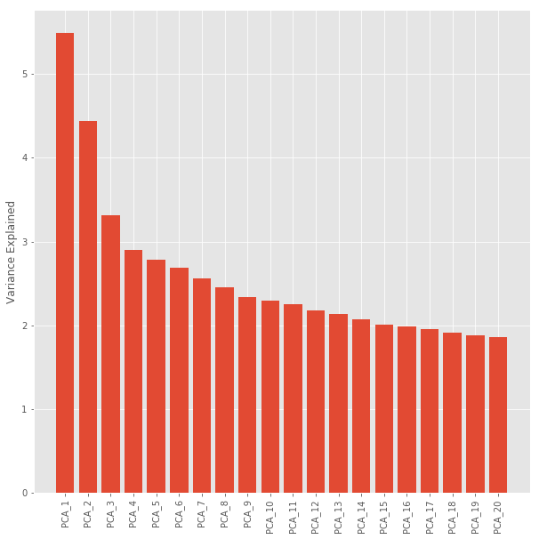

```python
# To be implemented
n_col_to_display=20

pca_range = np.arange(n_col_to_display) + 1
pca_names = ['PCA_%s' % i for i in pca_range]

plt.figure(figsize=(10,10))
plt.bar(pca_range, pca.explained_variance_[:n_col_to_display], align='center')
xticks = plt.xticks(pca_range, pca_names, rotation=90)
plt.ylabel('Variance Explained')
```

```
Text(0.5,0,'Proportion of Variance Explained')
```

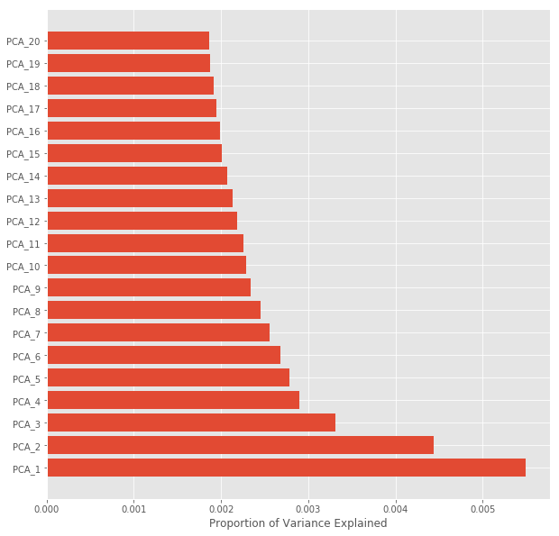

```python
n_col_to_display = 20

pca_range = np.arange(n_col_to_display) + 1
pca_names = ['PCA_%s' % i for i in pca_range]

plt.figure(figsize = (10,10))
plt.barh(pca_range, pca.explained_variance_ratio_[:n_col_to_display], align='center')
xticks = plt.yticks(pca_range, pca_names)
plt.xlabel('Proportion of Variance Explained')
```

## Classifying positive/negative review with PCA preprocessing

```python
x_train_scaled.shape, y_train.shape
```

```
((64071, 1000), (64071,))
```

```python
x_train_pca.shape, y_train.shape
```

```
((64071, 50), (64071,))
```

### Logistic Regression Classifier

#### Use standardized tf-idf vectors as features

```python
# Build a Logistic Regression Classifier, train with standardized tf-idf vectors

from sklearn.linear_model import LogisticRegression

# To be implemented
model_lrc = LogisticRegression()
model_lrc.fit(x_train_scaled, y_train)
```

```
LogisticRegression(C=1.0, class_weight=None, dual=False, fit_intercept=True,
          intercept_scaling=1, max_iter=100, multi_class='ovr', n_jobs=1,
          penalty='l2', random_state=None, solver='liblinear', tol=0.0001,
          verbose=0, warm_start=False)
```

```python
# Get score for training set
model_lrc.score(x_train_scaled, y_train)
```

```
0.8246944795617362
```

```python
# Get score for test set
model_lrc.score(x_test_scaled, y_test)
```

```
0.8160885255624325
```

#### Use (Stardardized + PCA) tf-idf vectors as features

```python
# Build a Logistic Regression Classifier, train with PCA tranformed X

from sklearn.linear_model import LogisticRegression

# To be implemented
model_lrc = LogisticRegression()
model_lrc.fit(x_train_pca, y_train)
```

```
LogisticRegression(C=1.0, class_weight=None, dual=False, fit_intercept=True,
          intercept_scaling=1, max_iter=100, multi_class='ovr', n_jobs=1,
          penalty='l2', random_state=None, solver='liblinear', tol=0.0001,
          verbose=0, warm_start=False)
```

```python
# Get score for training set
model_lrc.score(x_train_pca, y_train)
```

```
0.8004089213528741
```

```python
# Get score for test set, REMEMBER to use PCA-transformed X!
model_lrc.score(x_test_pca, y_test)
```

```
0.8007775987735998
```

#### You can plot the coefficients against principal components

```python
# To be implemented
pca_range = np.arange(pca.n_components_) + 1
pca_names = ['PC_%s' % i for i in pca_range]

df_coeffs = pd.DataFrame(list(zip(pca_names, model_lrc.coef_.flatten()))).sort_values(by=[1], ascending=False)
df_coeffs.columns = ['PCs', 'coeff']
df_coeffs
```

|  | PCs | coeff |
| --- | --- | --- |
| 2 | PC_3 | 0.425680 |
| 9 | PC_10 | 0.402304 |
| 11 | PC_12 | 0.144732 |
| 15 | PC_16 | 0.124117 |
| 25 | PC_26 | 0.082525 |
| 14 | PC_15 | 0.080644 |
| 13 | PC_14 | 0.057673 |
| 43 | PC_44 | 0.052956 |
| 34 | PC_35 | 0.051212 |
| 40 | PC_41 | 0.040718 |
| 20 | PC_21 | 0.036288 |
| 26 | PC_27 | 0.022999 |
| 45 | PC_46 | 0.020940 |
| 30 | PC_31 | 0.019036 |
| 41 | PC_42 | 0.018966 |
| 36 | PC_37 | 0.013621 |
| 46 | PC_47 | 0.012989 |
| 19 | PC_20 | 0.012906 |
| 37 | PC_38 | -0.003740 |
| 28 | PC_29 | -0.006463 |
| 24 | PC_25 | -0.006495 |
| 49 | PC_50 | -0.008631 |
| 48 | PC_49 | -0.020857 |
| 35 | PC_36 | -0.021115 |
| 42 | PC_43 | -0.022969 |
| 33 | PC_34 | -0.027666 |
| 18 | PC_19 | -0.030045 |
| 31 | PC_32 | -0.031405 |
| 47 | PC_48 | -0.036088 |
| 32 | PC_33 | -0.037882 |
| 38 | PC_39 | -0.050558 |
| 29 | PC_30 | -0.055660 |
| 21 | PC_22 | -0.055819 |
| 1 | PC_2 | -0.064612 |
| 16 | PC_17 | -0.069477 |
| 44 | PC_45 | -0.090081 |
| 27 | PC_28 | -0.093916 |
| 17 | PC_18 | -0.099965 |
| 4 | PC_5 | -0.101678 |
| 12 | PC_13 | -0.105799 |
| 3 | PC_4 | -0.119780 |
| 22 | PC_23 | -0.127587 |
| 8 | PC_9 | -0.139384 |
| 10 | PC_11 | -0.149860 |
| 39 | PC_40 | -0.158299 |
| 23 | PC_24 | -0.199624 |
| 6 | PC_7 | -0.257744 |
| 7 | PC_8 | -0.307728 |
| 5 | PC_6 | -0.436861 |
| 0 | PC_1 | -0.643095 |

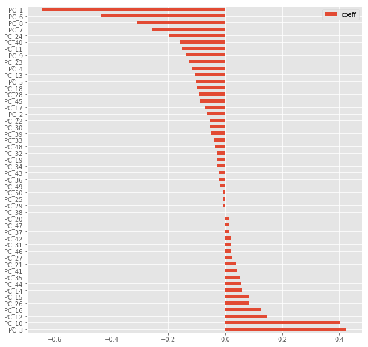

```python
ax = df_coeffs.plot.barh(figsize=(10,10))
t=np.arange(pca.n_components_)
ax.set_yticks(t)
ax.set_yticklabels(df_coeffs['PCs'])
plt.show()
```

### Random Forest Classifier

#### Use standardized tf-idf vectors as features

```python
# Build a Random Forest Classifier

from sklearn.ensemble import RandomForestClassifier

# To be implemented
model_rfc = RandomForestClassifier(max_depth=None, n_estimators = 20, min_samples_leaf=3, random_state=42)
model_rfc.fit(x_train_scaled, y_train)
```

```
RandomForestClassifier(bootstrap=True, class_weight=None, criterion='gini',
            max_depth=None, max_features='auto', max_leaf_nodes=None,
            min_impurity_decrease=0.0, min_impurity_split=None,
            min_samples_leaf=3, min_samples_split=2,
            min_weight_fraction_leaf=0.0, n_estimators=20, n_jobs=1,
            oob_score=False, random_state=42, verbose=0, warm_start=False)
```

```python
# Get score for training set
model_rfc.score(x_train_scaled, y_train)
```

```
0.9255513414805451
```

```python
# Get score for test set
model_rfc.score(x_test_scaled,y_test)
```

```
0.7880869925621741
```

#### Use (Stardardized + PCA) tf-idf vectors as features

```python
# Build a Random Forest Classifier

from sklearn.ensemble import RandomForestClassifier

# To be implemented
model_rfx = RandomForestClassifier(max_depth = None, n_estimators=20, min_samples_leaf=3, random_state=42)
model_rfx.fit(x_train_pca, y_train)
```

```
RandomForestClassifier(bootstrap=True, class_weight=None, criterion='gini',
            max_depth=None, max_features='auto', max_leaf_nodes=None,
            min_impurity_decrease=0.0, min_impurity_split=None,
            min_samples_leaf=3, min_samples_split=2,
            min_weight_fraction_leaf=0.0, n_estimators=20, n_jobs=1,
            oob_score=False, random_state=42, verbose=0, warm_start=False)
```

```python
# Get score for training set
model_rfc.score(x_train_pca, y_train)
```

[output not shown]

```python
# Get score for test set, REMEMBER to use PCA-transformed X!
model_rfc.score(x_test_pca, y_test)
```

[output not shown]

#### Q: What do you see from the training result and the test result?

```python
# To be implemented
pca_range = np.arange(pca.n_components_)+1
pca_names = ['PC_%s' %i for i in pca_range]

df_coeffs = pd.DataFrame(list(zip(pca_names, model_rfc.feature_importances_))).sort_values(by=[1], ascending=False)
df_coeffs.columns = ['PCs', 'feature importance']
df_coeffs
```

|  | PCs | feature importance |
| --- | --- | --- |
| 27 | PC_28 | 0.044692 |
| 39 | PC_40 | 0.008936 |
| 48 | PC_49 | 0.003029 |
| 44 | PC_45 | 0.001969 |
| 42 | PC_43 | 0.001637 |
| 17 | PC_18 | 0.001585 |
| 7 | PC_8 | 0.001439 |
| 10 | PC_11 | 0.001110 |
| 46 | PC_47 | 0.001106 |
| 1 | PC_2 | 0.000896 |
| 33 | PC_34 | 0.000866 |
| 41 | PC_42 | 0.000623 |
| 38 | PC_39 | 0.000608 |
| 19 | PC_20 | 0.000532 |
| 16 | PC_17 | 0.000518 |
| 28 | PC_29 | 0.000486 |
| 5 | PC_6 | 0.000384 |
| 32 | PC_33 | 0.000381 |
| 31 | PC_32 | 0.000340 |
| 18 | PC_19 | 0.000326 |
| 13 | PC_14 | 0.000307 |
| 35 | PC_36 | 0.000297 |
| 11 | PC_12 | 0.000283 |
| 25 | PC_26 | 0.000257 |
| 20 | PC_21 | 0.000256 |
| 49 | PC_50 | 0.000235 |
| 21 | PC_22 | 0.000233 |
| 24 | PC_25 | 0.000233 |
| 47 | PC_48 | 0.000229 |
| 0 | PC_1 | 0.000226 |
| 29 | PC_30 | 0.000215 |
| 4 | PC_5 | 0.000214 |
| 30 | PC_31 | 0.000200 |
| 37 | PC_38 | 0.000193 |
| 8 | PC_9 | 0.000192 |
| 34 | PC_35 | 0.000188 |
| 2 | PC_3 | 0.000186 |
| 23 | PC_24 | 0.000179 |
| 45 | PC_46 | 0.000147 |
| 43 | PC_44 | 0.000143 |
| 15 | PC_16 | 0.000141 |
| 9 | PC_10 | 0.000117 |
| 12 | PC_13 | 0.000098 |
| 36 | PC_37 | 0.000093 |
| 3 | PC_4 | 0.000092 |
| 6 | PC_7 | 0.000069 |
| 14 | PC_15 | 0.000062 |
| 40 | PC_41 | 0.000060 |
| 26 | PC_27 | 0.000049 |
| 22 | PC_23 | 0.000040 |

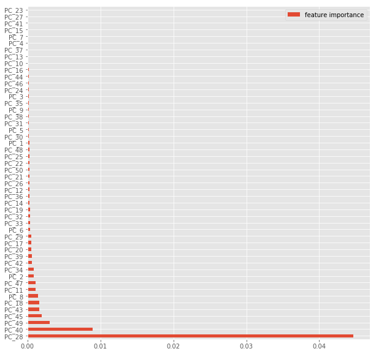

```python
ax=df_coeffs.plot.barh(figsize=(10,10))
t=np.arange(pca.n_components_)
ax.set_yticks(t)
ax.set_yticklabels(df_coeffs['PCs'])
plt.show()
```

## Extra Credit #1: Can you cluster restaurants from their category information?

Hint: a business may have mutiple categories, e.g. a restaurant can have both "Restaurants" and "Korean"

```python
# To be implemented
```

## Extra Credit #2: Can you try different distance/similarity metrics for clusterings, e.g. Pearson correlation, Jaccard distance, etc.

Hint: You can take a look at [scipy](http://docs.scipy.org/doc/scipy/reference/generated/scipy.spatial.distance.pdist.html#scipy.spatial.distance.pdist) documentations to use other distances

#### Q: How do you compare with Cosine distance or Euclidean distance?

```python
# To be implemented
```

## Extra Credit #3: Can you cluster categories from business entities? What does it mean by a cluster?

Hint: Think the example where words can be clustered from the transposed tf-idf matrix.

```python
# To be implemented
```

## Extra Credit #4: What are the characteristics of each of the clustered ? For each cluster, which restaurant can best represent ("define") its cluster?

Hint: how to interpret "best"?

```python
# To be implemented
```

## Extra Credit #5: Can you think of other use cases that clustering can be used?

Hint: of course you can make use of other yelp dataset. You can try anything you want as long as you can explain it.

```python
# To be implemented
```